# Risk table

### Constructing a table with numbers at risk

Now we make our risk table. This part does not depend on the previous plots, `base`, `inner`, `outer` or `pip`.

First, we restrict to observations from our data where there is a number at risk, and for clarity we include only relevant variables.

```r
# the relevant data
atrisk_survival <- survival |>
  filter(is.na(natrisk) == F) |>
  select(x, time, natrisk)
```

#### Plotting numbers in a coordinate system

The very basic part of the plot consists of numbers written in a coordinate system. You need to start a new `ggplot` using the data `atrisk_survival`. The necessary aesthetics are `x`, `y`, and `label`. The `geom_` you need for the risk table is called `geom_text()`. Make the plot.

**Hint**

The exposure variable goes into the `y`-aesthetic.

**Solution**

```r
ggplot(atrisk_survival, aes(x = time, y = x, label = natrisk)) +
  geom_text()
```

#### Stripping the plot of noise

We want to remove almost everything except for the numbers in the risk table. The built-in theme `theme_void()` removes everything except the data used in the plot. Add `theme_void()` with `base_size` specified as you have done for other themes.

**Solution**

```r
ggplot(atrisk_survival, aes(x = time, y = x, label = natrisk)) +
  geom_text() +
  theme_void(base_size = bsize)
```

**`base_size` and text size**

At this point `base_size` actually does not affect anything. The size of the text can be modified by the parameter `size` inside `geom_text()`. `base_size` is not used until we reinsert the labels on the y-axis.

#### Recreating the y-axis labels

We want to get the labels on the y-axes (the levels of the exposure) back into the plot. To do so we add a custom theme, where we set `axis.text.y` to `element_text(hjust = 1, color = mypal)`. (Try different values for `hjust` to see what it does.) You will probably get a warning, but it should be safe to ignore in this situation.

**Hint**

As previously noted, the order of the built-in theme (`theme_void()`) and your custom theme is important.

**Solution**

```r
ggplot(atrisk_survival, aes(x = time, y = x, label = natrisk)) +
  geom_text() +
  theme_void(base_size = bsize) +
  theme(axis.text.y = element_text(hjust = 1, color = mypal))
```

**Text colors**

If you want the text in the risk table to take the same colors as the curves, you can add a `color` aesthetic to your plot. If you do so, make sure to remove the legend as you did in `geom_stepribbon()`.

#### Adding a title

Now we add a title to the risk table (so readers will know it shows numbers at risk). This can be done using the function `ggtitle()`. Simply specify the title you want the risk table to have in `ggtitle()`.

**Hint**

The title should be included as a string (use quotation marks).

**Solution**

```r
ggplot(atrisk_survival, aes(x = time, y = x, label = natrisk)) +
  geom_text() +
  theme_void(base_size = bsize) +
  theme(axis.text.y = element_text(hjust = 1, color = mypal)) +
  ggtitle("At risk")
```

#### Editing the appearance of the title

The title might need some adjustment both with regards to position and size. Within your custom `theme` you can modify the title using the parameter `plot.title` which can be edited using `element_text()` (which you also use for `axis.text.y`). Try setting `size` to `bsize` inside `element_text()` and tinker a bit with `hjust` until you are happy with its placement. When you are happy with the look of the risk table, make it into an object called `risktable`.

**Appearance**

At this stage it can be hard to tell what will look good when combining the risk table and the curves. Consider revising the parameters of the risk table once you have the complete plot.

**Hint**

You can use negative values for `hjust` if you prefer.

**Solution**

```r
risktable <- ggplot(atrisk_survival, aes(x = time, y = x, label = natrisk)) +
  geom_text() +
  theme_void(base_size = bsize) +
  theme(axis.text.y = element_text(hjust = 1, color = mypal),
        plot.title = element_text(hjust = -.1, size = bsize)) +
  ggtitle("At risk")
```

#### The finished risk table

Your risk table should now look something like this (with allowance for differences based on personal preferences):

**Show plot**

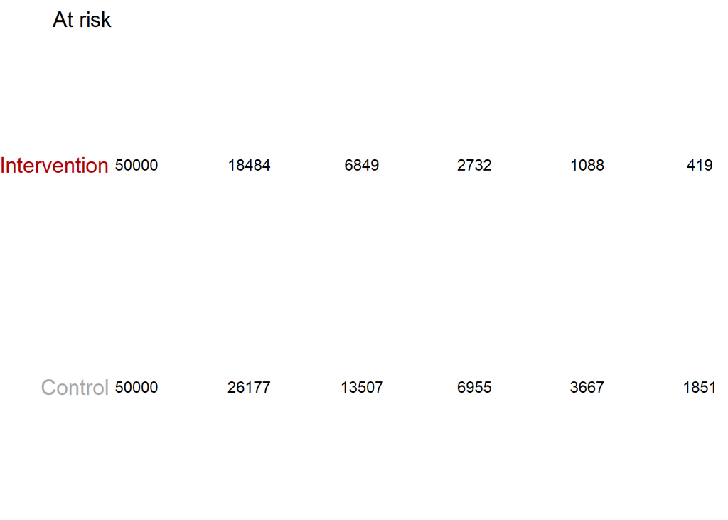